# 📘 Notebook 08: Autoencoders and Variational Autoencoders, Learning to Compress and to Create

### Course: *From Papers to Practice: Landmark Deep Learning Architectures*

**Instructor:** Ioannis Tsioulis

*Papers: Hinton and Salakhutdinov (2006) · Kingma and Welling (2013)*

> 💡 **This notebook is already run.** Every number and picture below was produced by the code above it, and each result is followed by a comment that explains what it shows. You can read it without running anything, or choose **Runtime → Run all** in Colab.

> ⏱️ **Training time and limitations.** An autoencoder and a variational autoencoder, both small fully connected networks, train on the 60,000 MNIST digits for 10 epochs each: about **eight minutes** in total on a laptop processor, about a minute on a Colab GPU. The 2006 paper pretrained deep autoencoders layer by layer with restricted Boltzmann machines, a step no longer needed with modern optimisers; we train end to end with Adam. Our VAE uses a **two-dimensional** code so that its whole "imagination" can be drawn on one page; real VAEs use dozens or hundreds of dimensions and convolutional layers, and produce sharper images.

## 🎯 Learning objectives

By the end of this notebook you will be able to:

- Explain an **autoencoder**: an encoder that compresses, a **bottleneck code**, a decoder that rebuilds
- Compare a learned compression with **PCA** at the same size
- Explain why a plain autoencoder is a poor **generator** of new images
- Explain the **variational autoencoder (VAE)**: codes as distributions, the **reparameterisation trick**, and the two parts of its loss
- Draw the **latent space** of a VAE and generate new digits by walking through it

> **Prerequisites:** [Notebook 02: LeNet-5](https://colab.research.google.com/github/giannis00/giannis00.github.io/blob/main/assets/jupyter/from-papers-to-practice/02_lenet5.ipynb) for MNIST, and PCA from [From Questions to Answers, Notebook 08](https://colab.research.google.com/github/giannis00/giannis00.github.io/blob/main/assets/jupyter/from-questions-to-answers/08_fashion_mnist.ipynb).

> 🔭 **Why this notebook matters:** every network so far mapped an input to a **label**. Autoencoders learn without labels, by rebuilding their own input, and the VAE turned this into one of the first deep **generative** models. Today's image generators still contain one: Stable Diffusion runs its diffusion process (Notebook 12) inside the compressed code of a VAE.

## 1. The papers

> 📄 G. E. Hinton and R. R. Salakhutdinov, [*Reducing the Dimensionality of Data with Neural Networks*](https://doi.org/10.1126/science.1127647), Science 313, 2006.

> 📄 D. P. Kingma and M. Welling, [*Auto-Encoding Variational Bayes*](https://arxiv.org/abs/1312.6114), ICLR 2014 (arXiv 2013).

### Intuition first

An **autoencoder** is trained to output its own input. That sounds pointless, until the middle of the network is made **narrow**: a 784-pixel image must pass through, say, 32 numbers. To rebuild the image from 32 numbers, the network has to discover what matters in digits (stroke thickness, slant, loops) and discard the rest. The first half, the **encoder**, learns to compress; the second half, the **decoder**, learns to decompress; the 32 numbers are the **code** (or **latent** representation).

Hinton and Salakhutdinov showed in 2006 that such a network, if deep, compresses images far better than PCA, the classic linear method. Kingma and Welling then asked how to **generate** new images: pick a code, run the decoder. Section 4 shows why that works poorly for a plain autoencoder, and Section 5 how the VAE fixes it.

```python
import warnings
warnings.filterwarnings("ignore")

import gzip
import time
import urllib.request
import numpy as np
import matplotlib.pyplot as plt
import torch
import torch.nn as nn
import torch.nn.functional as F
from sklearn.decomposition import PCA

torch.manual_seed(0)
torch.set_num_threads(4)
plt.rcParams["figure.dpi"] = 80

MIRROR = "https://ossci-datasets.s3.amazonaws.com/mnist/"
def read_idx(name, header):
    return np.frombuffer(gzip.decompress(urllib.request.urlopen(MIRROR + name).read()), dtype=np.uint8, offset=header)
X_train = torch.tensor(read_idx("train-images-idx3-ubyte.gz", 16).reshape(-1, 784), dtype=torch.float32) / 255
X_test = torch.tensor(read_idx("t10k-images-idx3-ubyte.gz", 16).reshape(-1, 784), dtype=torch.float32) / 255
y_test = read_idx("t10k-labels-idx1-ubyte.gz", 8)
print("train", tuple(X_train.shape), " test", tuple(X_test.shape))
```

```
train (60000, 784)  test (10000, 784)
```

## 2. An autoencoder with a 32-number code

```python
class Autoencoder(nn.Module):
    def __init__(self, code=32):
        super().__init__()
        self.encoder = nn.Sequential(nn.Linear(784, 256), nn.ReLU(), nn.Linear(256, 128), nn.ReLU(), nn.Linear(128, code))
        self.decoder = nn.Sequential(nn.Linear(code, 128), nn.ReLU(), nn.Linear(128, 256), nn.ReLU(), nn.Linear(256, 784), nn.Sigmoid())

    def forward(self, x):
        return self.decoder(self.encoder(x))

def train(model, loss_fn, epochs=10, batch=256):
    opt = torch.optim.Adam(model.parameters(), lr=1e-3)
    start = time.time()
    for epoch in range(epochs):
        order = torch.randperm(len(X_train))
        for i in range(0, len(X_train), batch):
            x = X_train[order[i:i + batch]]
            loss = loss_fn(model, x)
            opt.zero_grad(); loss.backward(); opt.step()
    print(f"trained in {time.time() - start:.0f} s")

ae_loss = lambda model, x: F.mse_loss(model(x), x)
torch.manual_seed(0)
ae = Autoencoder(32)
train(ae, ae_loss)

with torch.no_grad():
    ae_error = F.mse_loss(ae(X_test), X_test).item()
pca = PCA(n_components=32).fit(X_train.numpy())
pca_rebuilt = pca.inverse_transform(pca.transform(X_test.numpy()))
pca_error = float(((pca_rebuilt - X_test.numpy()) ** 2).mean())
print(f"reconstruction error with 32 numbers per image:  PCA {pca_error:.4f}   autoencoder {ae_error:.4f}")
```

```
trained in 182 s
```

```
reconstruction error with 32 numbers per image:  PCA 0.0168   autoencoder 0.0120
```

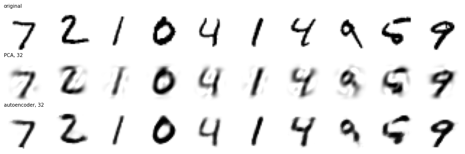

```python
with torch.no_grad():
    rebuilt = ae(X_test[:10]).numpy()
fig, axes = plt.subplots(3, 10, figsize=(12, 4))
for i in range(10):
    for row, (img, name) in enumerate([(X_test[i].numpy(), "original"), (pca_rebuilt[i], "PCA, 32"), (rebuilt[i], "autoencoder, 32")]):
        axes[row, i].imshow(img.reshape(28, 28), cmap="gray_r", vmin=0, vmax=1)
        axes[row, i].axis("off")
        if i == 0:
            axes[row, i].set_title(name, fontsize=9, loc="left")
plt.tight_layout()
plt.show()
```

**What we see.** With the same budget of **32 numbers** per image, the autoencoder rebuilds the test digits with an error of **0.0120**, against **0.0168** for PCA: about **30% less**. The pictures show the difference: PCA's digits are surrounded by grey ghosts of other digits (PCA can only add and subtract fixed patterns), while the autoencoder's are clean, slightly smoothed copies of the originals. A non-linear compression captures the shape of digits far better than a linear one, which is exactly the claim of the 2006 paper.

## 3. A two-number code, and its map

To **see** the code, we train a second autoencoder that compresses each digit into only **2** numbers, and draw every test digit as a point.

```
trained in 132 s
```

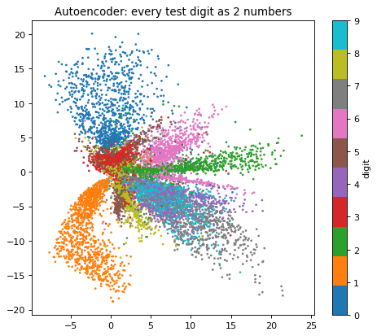

```
range of the codes: x from -8.2 to 23.8   y from -18.8 to 20.1
```

```python
torch.manual_seed(0)
ae2 = Autoencoder(2)
train(ae2, ae_loss)
with torch.no_grad():
    codes_ae = ae2.encoder(X_test).numpy()
plt.figure(figsize=(7, 6))
sc = plt.scatter(codes_ae[:, 0], codes_ae[:, 1], c=y_test, cmap="tab10", s=2)
plt.colorbar(sc, ticks=range(10), label="digit")
plt.title("Autoencoder: every test digit as 2 numbers")
plt.show()
print("range of the codes: x from", codes_ae[:, 0].min().round(1), "to", codes_ae[:, 0].max().round(1),
      "  y from", codes_ae[:, 1].min().round(1), "to", codes_ae[:, 1].max().round(1))
```

**What we see.** With only two numbers, the autoencoder still organises the digits: each colour (digit) occupies its own region, 0s at the top left, 1s at the bottom left, 2s in a band to the right. But look at the **shape** of this map. The codes run from about -8 to 24 on one axis and -19 to 20 on the other; some digits form long thin rays, others are packed into a small crowded centre, and large areas are empty. Nothing told the network what shape to give its code, so it chose one that suits rebuilding, not sampling.

## 4. Why a plain autoencoder is a poor generator

To create a new digit, we would pick a point in the code space and decode it. Here is what the decoder produces on a regular grid of points covering the area where the codes lie.

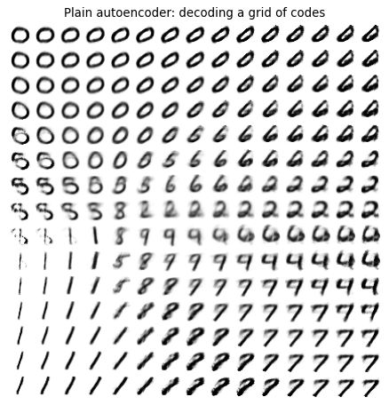

```python
def decode_grid(decoder, xs, ys):
    canvas = np.zeros((28 * len(ys), 28 * len(xs)))
    with torch.no_grad():
        for r, yv in enumerate(ys):
            for c, xv in enumerate(xs):
                img = decoder(torch.tensor([[xv, yv]], dtype=torch.float32)).numpy().reshape(28, 28)
                canvas[r * 28:(r + 1) * 28, c * 28:(c + 1) * 28] = img
    return canvas

xs = np.linspace(codes_ae[:, 0].min(), codes_ae[:, 0].max(), 15)
ys = np.linspace(codes_ae[:, 1].max(), codes_ae[:, 1].min(), 15)
plt.figure(figsize=(7, 7))
plt.imshow(decode_grid(ae2.decoder, xs, ys), cmap="gray_r")
plt.axis("off")
plt.title("Plain autoencoder: decoding a grid of codes")
plt.show()
```

**What we see.** Decoding a grid over the rectangle that contains the codes gives digit-like images in the regions where training digits lie (the 0s, the 1s, the 7s along the bottom), and smeared blends or odd hybrids in between (the faint, blurred shapes in the middle rows). The decoder has only learned what to do on the paths where real codes landed. For generation this raises a practical question with no good answer: **where** should we sample? The map has no known shape, so a random point may fall in a gap. With more code dimensions the problem gets much worse, because almost all of a high-dimensional space is gap.

## 5. The variational autoencoder

### Intuition first

The VAE makes two changes:

1. The encoder no longer outputs **a point** but a small **cloud**: a mean $\mu$ and a spread $\sigma$ for each code dimension. During training, the code is a random sample from that cloud, so the decoder must work for every point **near** each digit's code, not just one exact point.
2. A second term in the loss, the **KL divergence**, pulls every cloud towards a standard normal distribution (mean 0, spread 1). This packs all digits into one compact, gap-free region around the origin.

Together they make the whole code space meaningful: any point near the origin decodes to something digit-like.

**The reparameterisation trick.** Sampling is random, and randomness has no gradient. Kingma and Welling rewrote the sample as $z = \mu + \sigma \cdot \epsilon$ with $\epsilon$ drawn from a standard normal: the randomness is now an input, and gradients flow through $\mu$ and $\sigma$ as usual.

$$\text{loss} = \underbrace{\text{reconstruction error}}_{\text{rebuild the image}} + \underbrace{D_{KL}\big(\mathcal{N}(\mu, \sigma^2)\,\|\,\mathcal{N}(0, 1)\big)}_{\text{keep codes compact}}$$

```
trained in 161 s
```

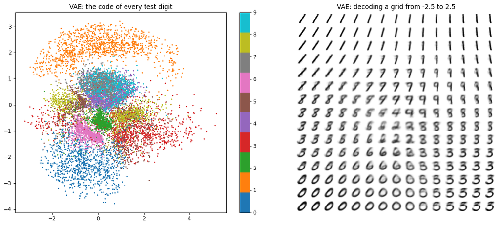

```
range of the codes: x from -3.2 to 5.2   y from -3.8 to 3.2
```

```python
class VAE(nn.Module):
    def __init__(self, code=2):
        super().__init__()
        self.body = nn.Sequential(nn.Linear(784, 256), nn.ReLU(), nn.Linear(256, 128), nn.ReLU())
        self.mu = nn.Linear(128, code)
        self.log_var = nn.Linear(128, code)
        self.decoder = nn.Sequential(nn.Linear(code, 128), nn.ReLU(), nn.Linear(128, 256), nn.ReLU(), nn.Linear(256, 784), nn.Sigmoid())

    def forward(self, x):
        h = self.body(x)
        mu, log_var = self.mu(h), self.log_var(h)
        z = mu + torch.exp(0.5 * log_var) * torch.randn_like(mu)     # the reparameterisation trick
        return self.decoder(z), mu, log_var

def vae_loss(model, x):
    rebuilt, mu, log_var = model(x)
    reconstruction = F.binary_cross_entropy(rebuilt, x, reduction="sum") / len(x)
    kl = -0.5 * torch.sum(1 + log_var - mu ** 2 - log_var.exp()) / len(x)
    return reconstruction + kl

torch.manual_seed(0)
vae = VAE(2)
train(vae, vae_loss)
with torch.no_grad():
    codes_vae = vae.mu(vae.body(X_test)).numpy()
fig, axes = plt.subplots(1, 2, figsize=(14, 6))
sc = axes[0].scatter(codes_vae[:, 0], codes_vae[:, 1], c=y_test, cmap="tab10", s=2)
axes[0].set_title("VAE: the code of every test digit")
plt.colorbar(sc, ax=axes[0], ticks=range(10))
grid = np.linspace(2.5, -2.5, 15)
axes[1].imshow(decode_grid(vae.decoder, -grid, grid), cmap="gray_r")
axes[1].axis("off")
axes[1].set_title("VAE: decoding a grid from -2.5 to 2.5")
plt.tight_layout()
plt.show()
print("range of the codes: x from", codes_vae[:, 0].min().round(1), "to", codes_vae[:, 0].max().round(1),
      "  y from", codes_vae[:, 1].min().round(1), "to", codes_vae[:, 1].max().round(1))
```

**What we see.** The VAE's map is very different. All codes now lie in a compact region around the origin, roughly from -3 to 5 and -4 to 3, shaped like the standard normal distribution the KL term pulls them towards. The digits still form neighbourhoods (1s at the top, 0s at the bottom, 3s to the right), but they **touch** each other without large gaps. Decoding a regular grid from -2.5 to 2.5 gives a smooth atlas of handwriting: 1s lean from left to right along the top, then turn into 7s and 9s, 8s blend into 3s and 5s, 0s appear at the bottom. Every point decodes to something digit-like, and neighbouring points to similar digits.

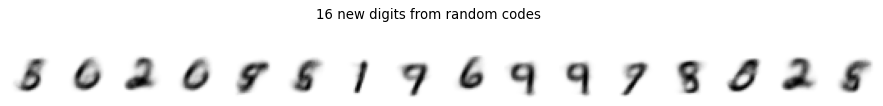

```python
torch.manual_seed(1)
with torch.no_grad():
    samples = vae.decoder(torch.randn(16, 2)).numpy()
fig, axes = plt.subplots(1, 16, figsize=(14, 1.3))
for ax, img in zip(axes, samples):
    ax.imshow(img.reshape(28, 28), cmap="gray_r"); ax.axis("off")
plt.suptitle("16 new digits from random codes", y=1.15)
plt.show()
```

**What we see.** Sixteen codes drawn at random from a standard normal distribution give sixteen new, recognisable digits (5, 0, 2, 0, 8, 5, 1, 7, 6, 9, ...), none of them copied from the training set. They are **blurry**: a two-number code cannot hold much detail, and the pixel-wise loss rewards safe, averaged strokes. This blurriness is the VAE's well-known weakness, and the motivation for GANs in the next notebook.

## ⚠️ Common pitfalls

- **Judging an autoencoder by how sharp its outputs are.** Mean squared error rewards blurry averages; blurriness is the price of a small code and a pixel-wise loss.
- **Sampling from a plain autoencoder.** Its code space has gaps and no known shape, so there is no principled way to pick a code; random points often fall between digits and decode to blends.
- **Forgetting the KL term,** or weighting it so weakly that the VAE becomes a plain autoencoder (or so strongly that it ignores the input).
- **Sampling without the reparameterisation trick.** `torch.normal(mu, sigma)` inside the model breaks the gradient to $\mu$ and $\sigma$.
- **Using the random sample $z$ to plot codes.** For the map, use the mean $\mu$; the sample adds noise to every point.

## ✏️ Exercises

### Exercise 1 (How small can the code be?)

Train autoencoders with codes of 2, 8 and 64 numbers (5 epochs each) and print their test reconstruction error. Where does adding more numbers stop helping much?

```python
# Your solution here:
```

**💡 Show solution**

```
for size in [2, 8, 64]:
    torch.manual_seed(0)
    m = Autoencoder(size)
    train(m, ae_loss, epochs=5)
    with torch.no_grad():
        print(f"code of {size:2d}: error {F.mse_loss(m(X_test), X_test).item():.4f}")
```

*The error falls steeply from 2 to 8 numbers and much more slowly after that: most of what distinguishes handwritten digits fits in a handful of numbers. This is the same diminishing return as PCA's explained variance curve.*

### Exercise 2 (Morphing)

Take the VAE codes of a test **1** and a test **7**, and decode 10 points on the straight line between them. Do the intermediate images look like digits?

```python
# Your solution here:
```

**💡 Show solution**

```
one, seven = codes_vae[np.where(y_test == 1)[0][0]], codes_vae[np.where(y_test == 7)[0][0]]
fig, axes = plt.subplots(1, 10, figsize=(12, 1.4))
with torch.no_grad():
    for ax, t in zip(axes, np.linspace(0, 1, 10)):
        z = torch.tensor([(1 - t) * one + t * seven], dtype=torch.float32)
        ax.imshow(vae.decoder(z).numpy().reshape(28, 28), cmap="gray_r"); ax.axis("off")
plt.show()
```

*Because the VAE's code space has no gaps, the path from 1 to 7 passes through plausible shapes: the stroke tilts, then a bar grows on top. If the line crosses the region of another digit, that digit appears on the way.*

### Exercise 3 (Anomaly detection)

An autoencoder trained on digits should rebuild digits well and **other** images badly. Use the 32-number autoencoder to compute the reconstruction error of 1,000 MNIST test digits and of 1,000 **Fashion-MNIST** images. Could the error tell the two apart?

```python
# Your solution here:
```

**💡 Show solution**

```
FASHION = "https://github.com/zalandoresearch/fashion-mnist/raw/master/data/fashion/"
fashion = torch.tensor(np.frombuffer(gzip.decompress(urllib.request.urlopen(FASHION + "t10k-images-idx3-ubyte.gz").read()),
                                     dtype=np.uint8, offset=16).reshape(-1, 784)[:1000], dtype=torch.float32) / 255
with torch.no_grad():
    err_digits = ((ae(X_test[:1000]) - X_test[:1000]) ** 2).mean(1)
    err_fashion = ((ae(fashion) - fashion) ** 2).mean(1)
print("median error, digits:", round(err_digits.median().item(), 4), "  clothes:", round(err_fashion.median().item(), 4))
threshold = err_digits.quantile(0.95)
print("share of clothes above the 95th percentile of digit errors:", round((err_fashion > threshold).float().mean().item(), 3))
```

*Clothes are rebuilt far worse than digits, so a threshold on the reconstruction error flags almost all of them as "not a digit". This is how autoencoders are used for **anomaly detection** in industry: train on normal data, flag what the model cannot rebuild.*

## 🔑 Key takeaways

- An **autoencoder** learns to compress and rebuild its input without labels; a deep one beats PCA at the same code size.
- Its code space has **gaps** and an arbitrary shape, so there is no good way to choose codes for new images.
- A **VAE** encodes each input as a **distribution**, adds a **KL term** that packs codes around the origin, and trains through the **reparameterisation trick**.
- The result is a smooth, gap-free **latent space** from which new examples can be sampled and between which one can morph.
- VAEs give blurry images on their own, but their compressed code is a building block of modern generators.

**Next:** *Notebook 09: Generative Adversarial Networks*, where two networks compete, one forging digits and one detecting forgeries, and the images become sharp.

*© Ioannis Tsioulis. *From Papers to Practice: Landmark Deep Learning Architectures*. Prepared for educational use.*